# FinalCode

**Analysis of factors influencing PM 2.5 level other than the Demographics of the city.**  
**The analysis is performed on the beijing data to understand how meteorological factors such as Temperature, Pressure, Dewpoint etc. influence PM2.5 level**

```python
import time
```

```python
s_time= time.time()

#import all the necessary packages that would be used across the project, to perform various operations.
import copy
import numpy as np
import pandas as pd
import seaborn as sns
import matplotlib as matplotlib
import matplotlib.pylab as plt
#Using other libraries
from sklearn.cluster import KMeans
import timeit
%matplotlib inline

e_time = time.time()

print(e_time-s_time)
```

```
26.399088859558105
```

**Download the data from the link provided below, the file will be downloded in your downloads folder.**

https://drive.google.com/file/d/1kub1IbC8vO6iWAfo7ceJW2tWyQ-o2oud/view?usp=sharing

**Place the downloaded file from the download folder to your current working directory. To know what is the current working directory of the note book, please run the following code below**

```python
import os
print(os.getcwd())
```

```
C:\Users\KVR\Documents\Python Scripts\Class examples\Project_Files
```

**C:\Users\KVR\Documents\Python Scripts\Class examples\Project_Files** This represent My **working directory**, Please run the above code to get yours.

**Intial analysis on data to understand data.**

Read the intial data, which is in csv format into the dataframe using pandas (pd)

```python
s_time= time.time()

Beijingdata = pd.read_csv("BeijingPM20100101_20151231.csv")
Beijingdata.head()

e_time = time.time()

print(e_time-s_time)
```

```
0.851642370223999
```

**Description of the dataset**

- **year**year of data in this row
- **month** : month of data in this row
- **day** : day of data in this row
- **hour** : hour of data in this row
- **season** : season of data in this row
- **PM** : PM2.5 concentration (ug/m^3)
- **DEWP** : Dew Point (Celsius Degree)
- **TEMP** : Temperature (Celsius Degree)
- **HUMI** : Humidity (%)
- **PRES** : Pressure (hPa)
- **cbwd** : Combined wind direction
- **Iws** : Cumulated wind speed (m/s)
- **precipitation** : hourly precipitation (mm)
- **Iprec** : Cumulated precipitation (mm)

**Data cleansing and preparing data for analysis**

- Missingno is a package, which helps to visualize how good our data quality is, the package represents the null values across each column with white spaces, which helps us to visualize how good the data is.
- To install this package, please open the anaconda command prompt and enter the following comand.
- **conda install -c conda-forge missingno**

```
18.198498010635376
```

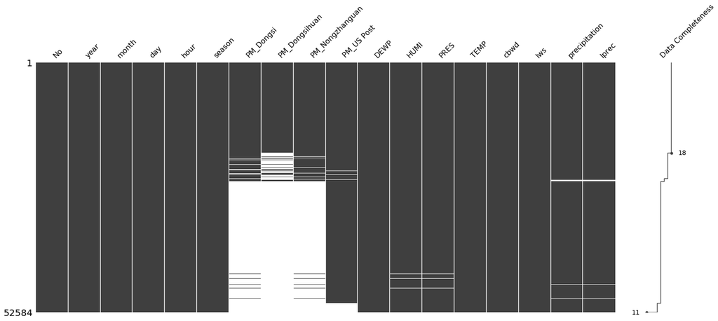

```python
s_time = time.time()

#check the data quality
import missingno as msno
msno.matrix(Beijingdata, labels=True, sort='descending')
#Data shows lot of discrepancies, there are too many whitespaces, which show we have a lot of NAN values

e_time = time.time()

print(e_time-s_time)
```

**The white spaces in the graph above depict all the NULL values with respect to each column in our intia dataset.**

Remove all the **NAN** values in the data, so that the analysis that we perform would be precise and yeild better results.

```python
s_time = time.time()

for i in Beijingdata.columns:
 Beijingdata = Beijingdata.dropna(subset=[i]) # remove Nan's from all columns

e_time = time.time()

print(e_time-s_time)
```

```
0.8427550792694092
```

Check for the data quality after removing all the rows with **NAN**, Data quality looks **strong.**

```
0.12332892417907715
```

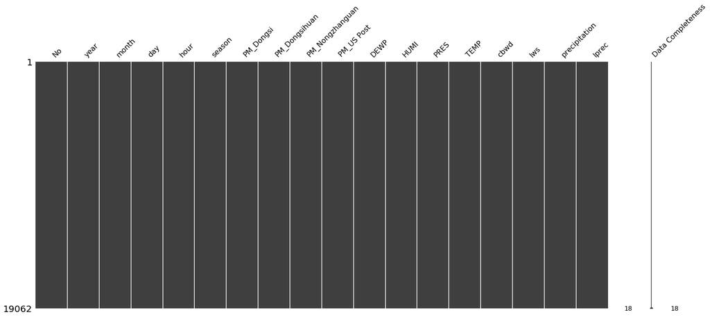

```python
s_time = time.time()

#check the data quality
import missingno as msno
msno.matrix(Beijingdata, labels=True, sort='descending')
#Data shows lot of discrepancies

e_time = time.time()

print(e_time-s_time)
```

**The data quality looks comeplete. We can go ahead and start preparing the data for analysis**

- Data has, **year, month and hour** columns. Merging these three columns, to make them into a **datatime** object would be helpful for our analysis.
- Below steps depict the code that adds datatimeobject to the dataframe
- **"Merged_Date_Time"** columns is succesfully added after executing the below step.

```python
s_time = time.time()

#To append Time, Date and hours and make a date and time object
import datetime
def getFullDate(row):
    time = str(row['month'])+"/"+ str(row["day"])+"/"+str(row["year"])
    date = datetime.datetime.strptime(time, "%m/%d/%Y")
    time = str(row["hour"]).split(":")
    date = date.replace(hour=int(time[0]))
    return date
Beijingdata["Merged_Date_Time"] = Beijingdata.apply(getFullDate, axis=1) #.apply() function applies function along input axis of DataFrame.
Beijingdata.head()#check if the "Merged_Date_Time" column has been appended to the dataframe.

e_time = time.time()

print(e_time-s_time)
```

```
1.7557499408721924
```

The dataset has PM2.5 level from various loactions in beijing

- PM_Dongsi
- PM_Dongsihuan
- PM_Nongzhanguan
- PM_US Post

To perform the analysis on PM2.5 we take the the average of PM 2.5 across all the locations into column **"Average_PM_Level"**, to depict the PM level of beijing in total.

```python
s_time = time.time()

def getAverageColumn(row):
    avg = (int(row["PM_Dongsi"]) + int(row["PM_Dongsihuan"]) + int(row["PM_Nongzhanguan"]) + int(row["PM_US Post"]))/4
    return avg
Beijingdata["Average_PM_Level"] = Beijingdata.apply(getAverageColumn, axis=1)
print(Beijingdata.head()) # Check if the column is added into the dataframe.

e_time = time.time()

print(e_time-s_time)
```

```
          No  year  month  day  hour  season  PM_Dongsi  PM_Dongsihuan  \
27824  27825  2013      3    5     8       1      117.0          166.0
27825  27826  2013      3    5     9       1      131.0          165.0
27826  27827  2013      3    5    10       1      141.0          173.0
27828  27829  2013      3    5    12       1      169.0          182.0
27829  27830  2013      3    5    13       1      169.0          169.0

       PM_Nongzhanguan  PM_US Post  DEWP  HUMI    PRES  TEMP cbwd   Iws  \
27824            140.0       150.0  -6.0  59.0  1019.0   1.0   cv  0.89
27825            152.0       163.0  -8.0  38.0  1019.0   5.0   cv  1.78
27826            128.0       172.0  -8.0  31.0  1018.0   8.0   cv  2.67
27828              3.0       181.0  -9.0  23.0  1017.0  11.0   cv  4.45
27829              3.0       187.0  -9.0  22.0  1015.0  12.0   cv  5.34

       precipitation  Iprec    Merged_Date_Time  Average_PM_Level
27824            0.0    0.0 2013-03-05 08:00:00            143.25
27825            0.0    0.0 2013-03-05 09:00:00            152.75
27826            0.0    0.0 2013-03-05 10:00:00            153.50
27828            0.0    0.0 2013-03-05 12:00:00            133.75
27829            0.0    0.0 2013-03-05 13:00:00            132.00
1.0355002880096436
```

**Explanatory analysis</p>**

**Run the scatter plot on all the variables to understand, the relation ship between each and every variable.**

```
10.618021249771118
```

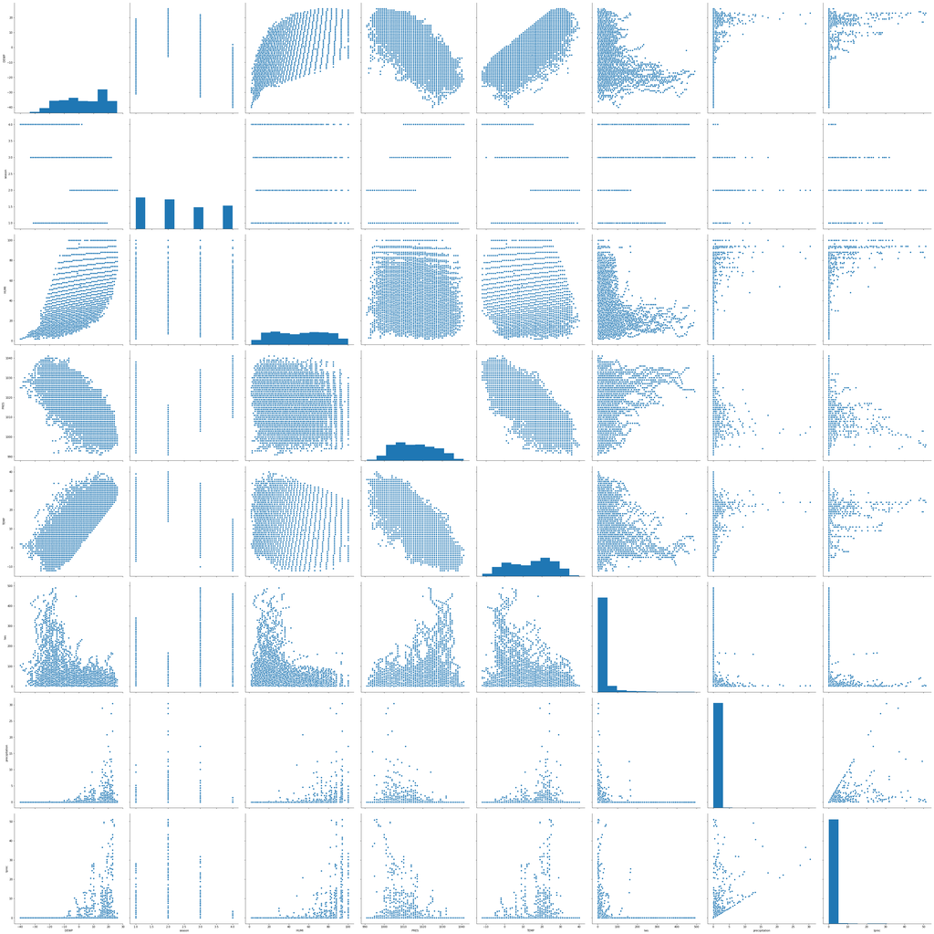

```python
s_time = time.time()

#Data looks consistent, let's run the pair plot to see the patterns
sns.pairplot(x_vars=['DEWP','season','HUMI','PRES','TEMP','Iws','precipitation','Iprec'], y_vars=['DEWP','season','HUMI','PRES','TEMP','Iws','precipitation','Iprec'], data=Beijingdata, size=6)

e_time = time.time()

print(e_time-s_time)
```

**There appears to be some kind of relation between some variables, let's Get a correlation matrix on all the variables to check the relation between variables**

```python
s_time = time.time()

print(Beijingdata.corr()) # To find the correlation matrix between all the variables

e_time = time.time()

print(e_time-s_time)
```

```
                        No      year     month       day      hour    season  \
No                1.000000  0.931279  0.044451  0.019538  0.000489  0.144295
year              0.931279  1.000000 -0.321200 -0.015120 -0.000749  0.030228
month             0.044451 -0.321200  1.000000  0.006562  0.000887  0.288563
day               0.019538 -0.015120  0.006562  1.000000 -0.004411 -0.008862
hour              0.000489 -0.000749  0.000887 -0.004411  1.000000 -0.003047
season            0.144295  0.030228  0.288563 -0.008862 -0.003047  1.000000
PM_Dongsi        -0.021616  0.006845 -0.081342  0.062343  0.013020  0.093606
PM_Dongsihuan    -0.013390  0.000714 -0.042598  0.058939 -0.027725  0.110676
PM_Nongzhanguan  -0.010063  0.007963 -0.054522  0.063964 -0.009939  0.129988
PM_US Post       -0.048438 -0.026898 -0.058819  0.064723 -0.007406  0.130447
DEWP              0.016269 -0.048169  0.174968  0.032852 -0.031822 -0.387904
HUMI              0.048811 -0.009947  0.154053  0.021411 -0.282398 -0.012938
PRES              0.065587  0.063800 -0.007009 -0.009354 -0.047587  0.548900
TEMP             -0.024631 -0.063512  0.111249  0.025575  0.173795 -0.530078
Iws               0.007742 -0.022488  0.079934  0.020688  0.070757  0.068297
precipitation    -0.002322 -0.005595  0.011590 -0.023667 -0.001734 -0.021116
Iprec            -0.024004 -0.026764  0.014369 -0.034810 -0.015174 -0.028647
Average_PM_Level -0.023887 -0.003058 -0.060171  0.063625 -0.008439  0.118417

                  PM_Dongsi  PM_Dongsihuan  PM_Nongzhanguan  PM_US Post  \
No                -0.021616      -0.013390        -0.010063   -0.048438
year               0.006845       0.000714         0.007963   -0.026898
month             -0.081342      -0.042598        -0.054522   -0.058819
day                0.062343       0.058939         0.063964    0.064723
hour               0.013020      -0.027725        -0.009939   -0.007406
season             0.093606       0.110676         0.129988    0.130447
PM_Dongsi          1.000000       0.932997         0.956478    0.950605
PM_Dongsihuan      0.932997       1.000000         0.957168    0.949723
PM_Nongzhanguan    0.956478       0.957168         1.000000    0.964450
PM_US Post         0.950605       0.949723         0.964450    1.000000
DEWP               0.128772       0.104788         0.087994    0.068458
HUMI               0.378693       0.393996         0.372966    0.378325
PRES               0.003100       0.034231         0.049382    0.070621
TEMP              -0.129857      -0.175545        -0.182110   -0.210023
Iws               -0.221884      -0.234589        -0.224400   -0.223276
precipitation     -0.025500      -0.027765        -0.026690   -0.026321
Iprec             -0.045879      -0.045712        -0.045851   -0.041843
Average_PM_Level   0.977359       0.978257         0.987346    0.984215

```

[output cut: 25 more lines]

```
hour                  -0.001734 -0.015174         -0.008439
season                -0.021116 -0.028647          0.118417
PM_Dongsi             -0.025500 -0.045879          0.977359
PM_Dongsihuan         -0.027765 -0.045712          0.978257
PM_Nongzhanguan       -0.026690 -0.045851          0.987346
PM_US Post            -0.026321 -0.041843          0.984215
DEWP                   0.084661  0.104338          0.099123
HUMI                   0.105190  0.148048          0.388213
PRES                  -0.063212 -0.085939          0.040307
TEMP                   0.042680  0.043737         -0.177991
Iws                   -0.013013 -0.017140         -0.230325
precipitation          1.000000  0.530704         -0.027077
Iprec                  0.530704  1.000000         -0.045639
Average_PM_Level      -0.027077 -0.045639          1.000000
0.2500274181365967
```

**Key take aways**

- **Temperature has **negative** relation with PM level**
- **Temperature has **positive** relation with Dew point**
- **Temperature has **negative** relation with Pressure**
- **Humidity has **positive** relation with PM level**
- **Humidity has **negative** relation with IWS(Wind speed)**
- **Pressure has **negative** relation with Dew point**

**Find trends and relation between different variables and PM_level**

Trend/ relation between **hour** and **PM Level**

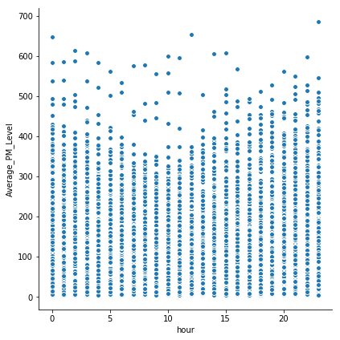

```python
#Shows that PM Level is high in winters than summers. This pattern is intact with the fact
sns.pairplot(x_vars=['hour'], y_vars=['Average_PM_Level'], data=Beijingdata, size=6)
```

```python
x =  Beijingdata.loc[(Beijingdata['month'] == 3) &Beijingdata['day'].isin([5])& Beijingdata['year'].isin([2015])]
print(x[['Average_PM_Level','hour']])
```

```
       Average_PM_Level  hour
45336             94.00     0
45337            106.25     1
45338            120.00     2
45339            134.00     3
45340            129.25     4
45341            120.25     5
45342            133.00     6
45343            135.75     7
45344            145.00     8
45345            158.00     9
45346            172.00    10
45347            109.25    11
45348             98.50    12
45349             74.00    13
45350             67.75    14
45351             72.00    15
45352             75.75    16
45353             78.75    17
45354             80.00    18
45355            104.00    19
45356            158.75    20
45357            187.00    21
45358            176.75    22
45359            145.50    23
```

**Numerical analysis depicts that there is some kind of pattern between **hour of the day** and **PM Level**</b>**

**Let's check of the trend is **prevalent** across the other days too.</b>**

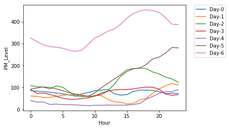

```python
#Plot the graph of PM_Level on hour for 7 days and check if the trend prevails
ListofallDays = []
for i in range(1,30):
    HourPmdatabyHour = []
    x =  Beijingdata.loc[(Beijingdata['month'] == 10) &Beijingdata['day'].isin([i])& Beijingdata['year'].isin([2014])]
    PM_Level = x.Average_PM_Level
    if(len(x.hour) == 24):
     ListofallDays.append(PM_Level)

Days = range(0,24)
fig = plt.figure()
#times = Functionofsimulation(100,10000,100)
ax1 = fig.add_subplot(111)
for d in range(0,(len(ListofallDays) - 1)):
 ax1.plot(Days,ListofallDays[d], '-',label="Day-"+ str(d))
plt.xlabel('Hour')
plt.ylabel('PM_Level')
plt.legend(bbox_to_anchor=(1.05, 1), loc=2, borderaxespad=0.)
plt.show()
```

Trend/ relation between **Month** and **PM Level**

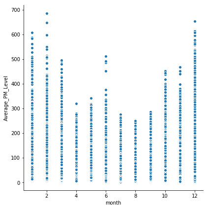

```python
#Shows that PM Level is high in winters than summers. This pattern is intact with the fact
sns.pairplot(x_vars=['month'], y_vars=['Average_PM_Level'], data=Beijingdata, size=6)
```

Trend/ relation between **Hour** and **Windspeed**

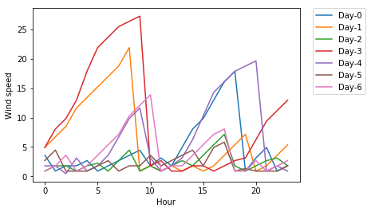

```python
#Plot the graph of PM_Level on hour for 7 days and check if the trend prevails
ListofallDays = []
for i in range(1,30):
    HourPmdatabyHour = []
    x =  Beijingdata.loc[(Beijingdata['month'] == 10) &Beijingdata['day'].isin([i])& Beijingdata['year'].isin([2014])]
    PM_Level = x.Iws
    if(len(x.hour) == 24):#account only when the day has entries for all the 24 hours
     ListofallDays.append(PM_Level)

Days = range(0,24)
fig = plt.figure()
ax1 = fig.add_subplot(111)
for d in range(0,(len(ListofallDays) - 1)):
 ax1.plot(Days,ListofallDays[d], '-',label="Day-"+ str(d))
plt.xlabel('Hour')
plt.ylabel('Wind speed')
plt.legend(bbox_to_anchor=(1.05, 1), loc=2, borderaxespad=0.)
plt.show()
```

**The trend of **Wind speed** and **PM-2.5**</b>**

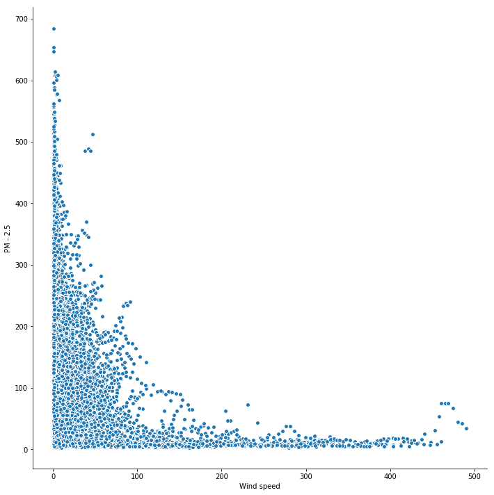

```python
sns.pairplot(x_vars=['Iws'], y_vars=['Average_PM_Level'], data=Beijingdata, size=10)
plt.xlabel('Wind speed')
plt.ylabel('PM - 2.5')
fig = plt.figure()
fig.set_size_inches(18.5, 10.5)
plt.show()
```

**As the Windspeed **Increases** PM2.5 level **decreases**.</b>**

**The trend of **Temperature** and **PM-2.5**</b>**

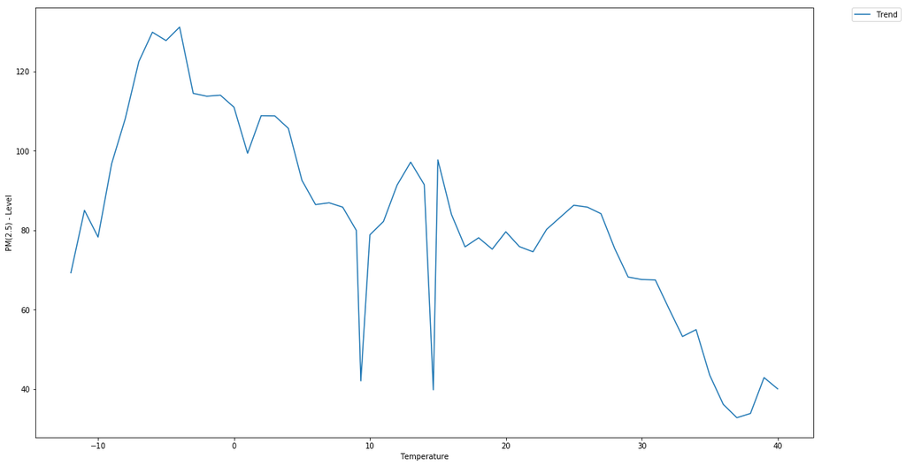

```python
#For the whole data this is how the graph is for all the hours
listofmodesbyhour = []
listofmeansbyTemperature = []
uniquelist =np.array(Beijingdata.TEMP.unique()).tolist()
uniquelist.sort();
for i in range(0,len(uniquelist)):

    x = Beijingdata[Beijingdata.TEMP == uniquelist[i]]
    listofmeansbyTemperature.append(x.Average_PM_Level.mean())

fig = plt.figure()
fig.set_size_inches(18.5, 10.5)
#times = Functionofsimulation(100,10000,100)
ax1 = fig.add_subplot(111)
ax1.plot(uniquelist,listofmeansbyTemperature, '-',label="Trend")
plt.xlabel('Temperature')
plt.ylabel('PM(2.5) - Level')
plt.legend(bbox_to_anchor=(1.05, 1), loc=2, borderaxespad=0.)

plt.show()
```

**As the Temperature **Increases** PM2.5 level **decreases**.</b>**

**The trend of **Temperature** and **Hour**</b>**

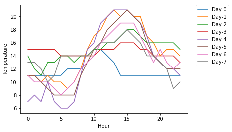

```python
#For the whole data this is how the graph is for all the hours
ListofallDays = []
for i in range(1,30):
    HourPmdatabyHour = []

    x =  Beijingdata.loc[(Beijingdata['month'] == 10) &Beijingdata['day'].isin([i])& Beijingdata['year'].isin([2014])]
    HourPmdatabyHour = x.TEMP
    if(len(x.hour) == 24):
     ListofallDays.append(HourPmdatabyHour)

Days = range(0,24)
fig = plt.figure()
ax1 = fig.add_subplot(111)
for d in range(0,len(ListofallDays)):
 ax1.plot(Days,ListofallDays[d], '-',label="Day-"+ str(d))
plt.xlabel('Hour')
plt.ylabel('Temperature')
plt.legend(bbox_to_anchor=(1.05, 1), loc=2, borderaxespad=0.)
plt.show()
```

**The trend of **Year** and **PM2.5 Level**</b>**

```python
Df = Beijingdata
```

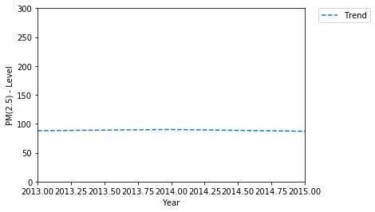

```python
#For the whole data this is how the graph is for all the hours
listofmeansbyyear = []
for i in Beijingdata.year.unique():
    x = Df[Df.year == i]
    listofmeansbyyear.append(x.Average_PM_Level.mean())

Years = []
for i in Beijingdata.year.unique():
    Years.append(i)
fig = plt.figure()
#times = Functionofsimulation(100,10000,100)
ax1 = fig.add_subplot(111)
ax1.plot(Years,listofmeansbyyear, '--',label="Trend")
plt.xlabel('Year')
plt.ylabel('PM(2.5) - Level')
plt.legend(bbox_to_anchor=(1.05, 1), loc=2, borderaxespad=0.)
plt.ylim(0, 300)
plt.xlim(2013, 2015)
plt.show()
```

**PM level remained **constant** for all the years, we considered in the data.</b>**

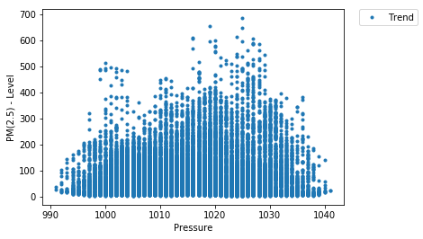

```python
#For the whole data this is how the graph is for all the hours
fig = plt.figure()
#times = Functionofsimulation(100,10000,100)
ax1 = fig.add_subplot(111)
ax1.plot(Beijingdata.PRES,Beijingdata.Average_PM_Level, '.',label="Trend")
plt.xlabel('Pressure')
plt.ylabel('PM(2.5) - Level')
plt.legend(bbox_to_anchor=(1.05, 1), loc=2, borderaxespad=0.)
plt.show()
```

```python
s_time = time.time()

DLIST = np.array(Beijingdata.cbwd).tolist()
newlist = []
for i in range(0,len(Beijingdata)):
    if((str(DLIST[i]) == "NW") | (str(DLIST[i]) == "NE")):
       newlist.append("North")
    elif((str(DLIST[i]) == "cv") | (str(DLIST[i]) == "SE")):
       newlist.append("South")

DataframeTest = pd.DataFrame(
    {'Pressure': Beijingdata.PRES,
     'PM-2.5 - level': Beijingdata.Average_PM_Level,
     'Type':newlist
    })

e_time = time.time()

print(e_time-s_time)
```

```
0.02306222915649414
```

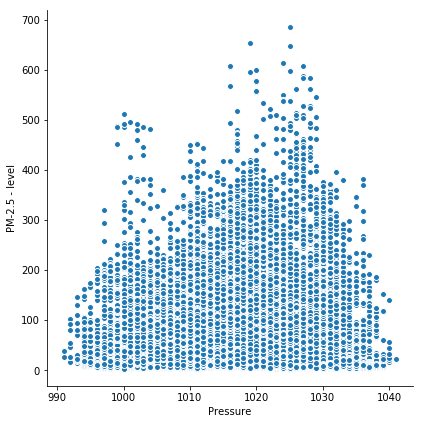

```python
#Data looks consistent, let's run the pair plot to see the patterns
sns.pairplot(x_vars=['Pressure'], y_vars=['PM-2.5 - level'], data=DataframeTest, size=6)
```

**Regression Analysis on PM2.5**

**Regression on full model, without accounting for the patterns in the data.**

```python
s_time = time.time()

import statsmodels.formula.api as sm
result = sm.ols(formula="Average_PM_Level ~ TEMP+DEWP+PRES+HUMI+Iws+Iprec+precipitation", data=Beijingdata).fit()
print (result.summary())

e_time = time.time()

print(e_time-s_time)
```

```
                            OLS Regression Results
==============================================================================
Dep. Variable:       Average_PM_Level   R-squared:                       0.230
Model:                            OLS   Adj. R-squared:                  0.230
Method:                 Least Squares   F-statistic:                     814.6
Date:                Sat, 21 Jul 2018   Prob (F-statistic):               0.00
Time:                        08:45:34   Log-Likelihood:            -1.0891e+05
No. Observations:               19062   AIC:                         2.178e+05
Df Residuals:                   19054   BIC:                         2.179e+05
Df Model:                           7
Covariance Type:            nonrobust
=================================================================================
                    coef    std err          t      P>|t|      [0.025      0.975]
---------------------------------------------------------------------------------
Intercept       835.5029    100.543      8.310      0.000     638.430    1032.576
TEMP             -2.6709      0.225    -11.890      0.000      -3.111      -2.231
DEWP              0.4947      0.228      2.172      0.030       0.048       0.941
PRES             -0.7454      0.097     -7.651      0.000      -0.936      -0.554
HUMI              1.0272      0.078     13.221      0.000       0.875       1.179
Iws              -0.2643      0.012    -21.793      0.000      -0.288      -0.241
Iprec            -3.4478      0.294    -11.719      0.000      -4.024      -2.871
precipitation    -1.5932      0.989     -1.612      0.107      -3.531       0.344
==============================================================================
Omnibus:                     5725.788   Durbin-Watson:                   0.097
Prob(Omnibus):                  0.000   Jarque-Bera (JB):            19669.374
Skew:                           1.507   Prob(JB):                         0.00
Kurtosis:                       6.960   Cond. No.                     1.93e+05
==============================================================================

Warnings:
[1] Standard Errors assume that the covariance matrix of the errors is correctly specified.
[2] The condition number is large, 1.93e+05. This might indicate that there are
strong multicollinearity or other numerical problems.
3.819976806640625
```

**Checking the VIF values to check for multi colleniarity between independent variables.**

```python
s_time = time.time()

from patsy import dmatrices
from statsmodels.stats.outliers_influence import variance_inflation_factor
# get y and X dataframes based on this regression:
y, X = dmatrices("Average_PM_Level ~ TEMP+DEWP+PRES+HUMI+Iws+Iprec+precipitation", Beijingdata, return_type='dataframe')
vif = pd.DataFrame()
vif["VIF Factor"] = [variance_inflation_factor(X.values, i) for i in range(X.shape[1])]
vif["features"] = X.columns
vif.round(1)

e_time = time.time()

print(e_time-s_time)
```

```
0.30776047706604004
```

```python
s_time = time.time()

import statsmodels.formula.api as sm
result = sm.ols(formula="DEWP ~ TEMP+HUMI", data=Beijingdata).fit()
print (result.summary())

e_time = time.time()

print(e_time-s_time)
```

```
                            OLS Regression Results
==============================================================================
Dep. Variable:                   DEWP   R-squared:                       0.973
Model:                            OLS   Adj. R-squared:                  0.973
Method:                 Least Squares   F-statistic:                 3.438e+05
Date:                Sat, 21 Jul 2018   Prob (F-statistic):               0.00
Time:                        08:45:34   Log-Likelihood:                -43277.
No. Observations:               19062   AIC:                         8.656e+04
Df Residuals:                   19059   BIC:                         8.658e+04
Df Model:                           2
Covariance Type:            nonrobust
==============================================================================
                 coef    std err          t      P>|t|      [0.025      0.975]
------------------------------------------------------------------------------
Intercept    -27.2041      0.042   -649.680      0.000     -27.286     -27.122
TEMP           0.9146      0.001    617.911      0.000       0.912       0.917
HUMI           0.3252      0.001    486.450      0.000       0.324       0.327
==============================================================================
Omnibus:                     8167.993   Durbin-Watson:                   0.201
Prob(Omnibus):                  0.000   Jarque-Bera (JB):            48841.964
Skew:                          -1.981   Prob(JB):                         0.00
Kurtosis:                       9.767   Cond. No.                         145.
==============================================================================

Warnings:
[1] Standard Errors assume that the covariance matrix of the errors is correctly specified.
0.02606940269470215
```

**The r(Square) value is so high, which means DEWP is being explained by TEMP and HUMI, So we can remove DEWP from regression.**

```python
s_time = time.time()

import statsmodels.formula.api as sm
result = sm.ols(formula="Average_PM_Level ~ TEMP+PRES+HUMI+Iws+Iprec+precipitation", data=Beijingdata).fit()
print (result.summary())

e_time = time.time()

print(e_time-s_time)
```

```
                            OLS Regression Results
==============================================================================
Dep. Variable:       Average_PM_Level   R-squared:                       0.230
Model:                            OLS   Adj. R-squared:                  0.230
Method:                 Least Squares   F-statistic:                     949.4
Date:                Sat, 21 Jul 2018   Prob (F-statistic):               0.00
Time:                        08:45:34   Log-Likelihood:            -1.0891e+05
No. Observations:               19062   AIC:                         2.178e+05
Df Residuals:                   19055   BIC:                         2.179e+05
Df Model:                           6
Covariance Type:            nonrobust
=================================================================================
                    coef    std err          t      P>|t|      [0.025      0.975]
---------------------------------------------------------------------------------
Intercept       820.6912    100.321      8.181      0.000     624.053    1017.329
TEMP             -2.2179      0.083    -26.609      0.000      -2.381      -2.054
PRES             -0.7440      0.097     -7.636      0.000      -0.935      -0.553
HUMI              1.1880      0.024     50.523      0.000       1.142       1.234
Iws              -0.2657      0.012    -21.935      0.000      -0.289      -0.242
Iprec            -3.4927      0.294    -11.900      0.000      -4.068      -2.917
precipitation    -1.6025      0.989     -1.621      0.105      -3.540       0.335
==============================================================================
Omnibus:                     5702.812   Durbin-Watson:                   0.097
Prob(Omnibus):                  0.000   Jarque-Bera (JB):            19472.479
Skew:                           1.503   Prob(JB):                         0.00
Kurtosis:                       6.935   Cond. No.                     1.92e+05
==============================================================================

Warnings:
[1] Standard Errors assume that the covariance matrix of the errors is correctly specified.
[2] The condition number is large, 1.92e+05. This might indicate that there are
strong multicollinearity or other numerical problems.
0.05313754081726074
```

```python
s_time = time.time()

from patsy import dmatrices
from statsmodels.stats.outliers_influence import variance_inflation_factor
# get y and X dataframes based on this regression:
y, X = dmatrices("Average_PM_Level ~ TEMP+PRES+HUMI+Iws+Iprec+precipitation", Beijingdata, return_type='dataframe')
vif = pd.DataFrame()
vif["VIF Factor"] = [variance_inflation_factor(X.values, i) for i in range(X.shape[1])]
vif["features"] = X.columns
vif.round(1)

e_time = time.time()

print(e_time-s_time)
```

```
0.07319521903991699
```

**Changes to the Regression Model to account for the patterns in the data.**

<b style= "color:orange;font-size:20px"> Clustering based on the patterns observed.</b>

**Accounting for the **High, Low, High** trend between **Hour** and **PM2.5 Level**</b>**

```python
Df = Beijingdata #Added To Avoid Errors in later steps.
#If Akshay can remove this and make sure the code works sequentially it will be great
```

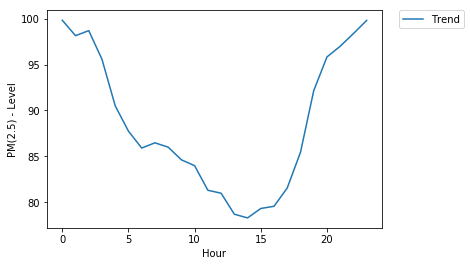

```python
#For the whole data this is how the graph is for all the hours
#average of the PM values by Hour
listofmeansbyhour = []
for i in range(0,24):
    x = Df[Df.hour == i]
    listofmeansbyhour.append(x.Average_PM_Level.mean())

#plot of Average PM values by hour with Hour
hours = []
for i in range(0,24):
    hours.append(i)
fig = plt.figure()
ax1 = fig.add_subplot(111)
ax1.plot(hours,listofmeansbyhour, '-',label="Trend")
plt.xlabel('Hour')
plt.ylabel('PM(2.5) - Level')
plt.legend(bbox_to_anchor=(1.05, 1), loc=2, borderaxespad=0.)
plt.show()
```

**The above graph clearly depicts the**High, Low, High** trend between **Hour** and **PM2.5 Level**</b>**

Make **clusters** in the dataset based on the **hours** to account for this trend</b>  
**To Decide on how many clusters to make, run the **elbow method** to find the steepest point.</b>**

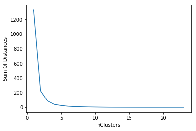

```
1.2467803955078125
```

```python
s_time = time.time()

Dataframeofhoursandpm = pd.DataFrame(
    {'PM-Level': listofmeansbyhour,
     'Hour': hours,
    })
rel_cols=['PM-Level']#,'Hour']
from sklearn.cluster import KMeans

#Determining number of clusters
nClusters=range(1,24)
sumDistances=[]
for n in nClusters:
    kmeans=KMeans(n_clusters=n).fit(Dataframeofhoursandpm[rel_cols])
    sumDistances.append(kmeans.inertia_) #Proxy for SSE
plt.plot(nClusters,sumDistances,'-')
plt.xlabel('nClusters')
plt.ylabel('Sum Of Distances')
plt.show()
Dataframeofhoursandpm['Cluster']=0

e_time = time.time()

print(e_time-s_time)
```

The above elbow curve, clearly depicts us to make **3 clusters** on the hours</b>  
**Cluster the data on **one Dimension** i.e. hours.</b>**

```
0.7874679565429688
```

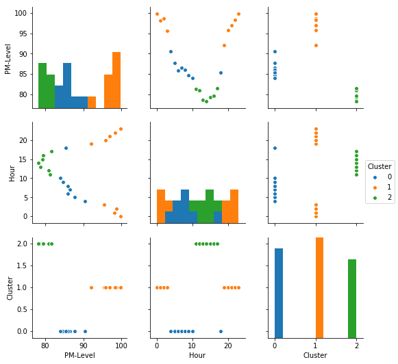

```python
s_time = time.time()

kmeans=KMeans(n_clusters=3).fit(Dataframeofhoursandpm[["PM-Level"]])
Dataframeofhoursandpm['Cluster']=kmeans.labels_
g = sns.pairplot(Dataframeofhoursandpm,hue='Cluster')

e_time = time.time()

print(e_time-s_time)
```

**Check what all hours comes into one category, to cluster them accordingly**

```python
print(Dataframeofhoursandpm["Cluster"])
```

```
0     1
1     1
2     1
3     1
4     0
5     0
6     0
7     0
8     0
9     0
10    0
11    2
12    2
13    2
14    2
15    2
16    2
17    2
18    0
19    1
20    1
21    1
22    1
23    1
Name: Cluster, dtype: int32
```

**Create, exta hour cluster column , to group the data accordingly**

```python
def Applycluster(row):
    if(int(row["hour"])<=3):
        return 1
    elif(int(row["hour"])<=10):
        return 2
    elif(int(row["hour"])<=17):
        return 0
    elif(int(row["hour"])==18):
        return 2
    elif(int(row["hour"]<=23)):
        return 1


Beijingdata["Hour_Cluster"] = Df.apply(Applycluster, axis=1)
```

**Create **Dummy variables** that would be used in regression, Now our regression will account for this pattern.</b>**

```python
DFDumy = Df.copy()
DFDumy[["Hour_Dummy1","Hour_Dummy2","Hour_Dummy3"]]= pd.get_dummies(Beijingdata["Hour_Cluster"])
```

**Check if the dummies are created properly.**

```python
DFDumy.head()
```

|  | No | year | month | day | hour | season | PM_Dongsi | PM_Dongsihuan | PM_Nongzhanguan | PM_US Post | ... | cbwd | Iws | precipitation | Iprec | Merged_Date_Time | Average_PM_Level | Hour_Cluster | Hour_Dummy1 | Hour_Dummy2 | Hour_Dummy3 |
| --- | --- | --- | --- | --- | --- | --- | --- | --- | --- | --- | --- | --- | --- | --- | --- | --- | --- | --- | --- | --- | --- |
| 27824 | 27825 | 2013 | 3 | 5 | 8 | 1 | 117.0 | 166.0 | 140.0 | 150.0 | ... | cv | 0.89 | 0.0 | 0.0 | 2013-03-05 08:00:00 | 143.25 | 2 | 0 | 0 | 1 |
| 27825 | 27826 | 2013 | 3 | 5 | 9 | 1 | 131.0 | 165.0 | 152.0 | 163.0 | ... | cv | 1.78 | 0.0 | 0.0 | 2013-03-05 09:00:00 | 152.75 | 2 | 0 | 0 | 1 |
| 27826 | 27827 | 2013 | 3 | 5 | 10 | 1 | 141.0 | 173.0 | 128.0 | 172.0 | ... | cv | 2.67 | 0.0 | 0.0 | 2013-03-05 10:00:00 | 153.50 | 2 | 0 | 0 | 1 |
| 27828 | 27829 | 2013 | 3 | 5 | 12 | 1 | 169.0 | 182.0 | 3.0 | 181.0 | ... | cv | 4.45 | 0.0 | 0.0 | 2013-03-05 12:00:00 | 133.75 | 0 | 1 | 0 | 0 |
| 27829 | 27830 | 2013 | 3 | 5 | 13 | 1 | 169.0 | 169.0 | 3.0 | 187.0 | ... | cv | 5.34 | 0.0 | 0.0 | 2013-03-05 13:00:00 | 132.00 | 0 | 1 | 0 | 0 |

5 rows × 24 columns

**Perform regression with the dummy variables**

```python
s_time = time.time()

import statsmodels.formula.api as sm
result = sm.ols(formula="Average_PM_Level ~ TEMP+PRES+HUMI+Iws+Iprec+precipitation+Hour_Dummy1+Hour_Dummy2", data=DFDumy).fit()
print (result.summary())

e_time = time.time()

print(e_time-s_time)
```

```
                            OLS Regression Results
==============================================================================
Dep. Variable:       Average_PM_Level   R-squared:                       0.262
Model:                            OLS   Adj. R-squared:                  0.262
Method:                 Least Squares   F-statistic:                     846.4
Date:                Sat, 21 Jul 2018   Prob (F-statistic):               0.00
Time:                        08:45:39   Log-Likelihood:            -1.0850e+05
No. Observations:               19062   AIC:                         2.170e+05
Df Residuals:                   19053   BIC:                         2.171e+05
Df Model:                           8
Covariance Type:            nonrobust
=================================================================================
                    coef    std err          t      P>|t|      [0.025      0.975]
---------------------------------------------------------------------------------
Intercept      1135.0932     99.139     11.449      0.000     940.771    1329.415
TEMP             -2.8357      0.085    -33.355      0.000      -3.002      -2.669
PRES             -1.0754      0.096    -11.159      0.000      -1.264      -0.886
HUMI              1.4289      0.025     57.744      0.000       1.380       1.477
Iws              -0.2467      0.012    -20.701      0.000      -0.270      -0.223
Iprec            -3.7976      0.288    -13.204      0.000      -4.361      -3.234
precipitation    -1.6987      0.968     -1.754      0.079      -3.597       0.199
Hour_Dummy1      42.6232      1.481     28.772      0.000      39.719      45.527
Hour_Dummy2      15.3945      1.236     12.458      0.000      12.972      17.817
==============================================================================
Omnibus:                     5343.653   Durbin-Watson:                   0.134
Prob(Omnibus):                  0.000   Jarque-Bera (JB):            17396.674
Skew:                           1.422   Prob(JB):                         0.00
Kurtosis:                       6.717   Cond. No.                     1.94e+05
==============================================================================

Warnings:
[1] Standard Errors assume that the covariance matrix of the errors is correctly specified.
[2] The condition number is large, 1.94e+05. This might indicate that there are
strong multicollinearity or other numerical problems.
0.2937798500061035
```

```python
s_time = time.time()

from patsy import dmatrices
from statsmodels.stats.outliers_influence import variance_inflation_factor
# get y and X dataframes based on this regression:
y, X = dmatrices("Average_PM_Level ~ TEMP+PRES+HUMI+Iws+Iprec+precipitation+Hour_Dummy1+Hour_Dummy2", DFDumy, return_type='dataframe')
vif = pd.DataFrame()
vif["VIF Factor"] = [variance_inflation_factor(X.values, i) for i in range(X.shape[1])]
vif["features"] = X.columns
vif.round(1)

e_time = time.time()

print(e_time-s_time)
```

```
0.12232542037963867
```

**Accounting for the **High, Low, High** trend between **Months** and **PM2.5 Level**</b>**

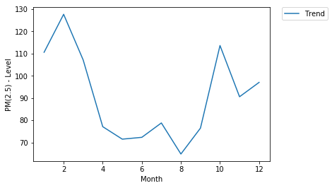

```python
#Analysis of months
#For the whole data this is how the graph is for all the months
#average of the PM values by Month
listofmeansbymonth = []
for i in range(1,13):
    x = Df[Df.month == i]
    listofmeansbymonth.append(x.Average_PM_Level.mean())
#plot of Average PM values by hour with Month
months = []
for i in range(1,13):
    months.append(i)
fig = plt.figure()
ax1 = fig.add_subplot(111)
ax1.plot(months,listofmeansbymonth, '-',label="Trend")
plt.xlabel('Month')
plt.ylabel('PM(2.5) - Level')
plt.legend(bbox_to_anchor=(1.05, 1), loc=2, borderaxespad=0.)
plt.show()
```

**The above graph clearly depicts the**High, Low, High** trend between **Month** and **PM2.5 Level**</b>**

Make **clusters** in the dataset based on the **Months** to account for this trend</b>  
**To Decide on how many clusters to make, run the **elbow method** to find the steepest point.</b>**

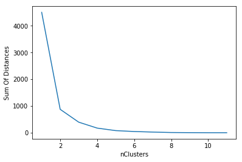

```python
#Analysis of months
#For the whole data this is how the graph is for all the hours

Dataframeofmonthsandpm = pd.DataFrame(
    {'PM-Level': listofmeansbymonth,
     'Month': months,
    })

rel_cols=['PM-Level']
from sklearn.cluster import KMeans

#Determining number of clusters
nClusters=range(1,12)
sumDistances=[]
for n in nClusters:
    kmeans=KMeans(n_clusters=n).fit(Dataframeofmonthsandpm[rel_cols])
    sumDistances.append(kmeans.inertia_) #Proxy for SSE
plt.plot(nClusters,sumDistances,'-')
plt.xlabel('nClusters')
plt.ylabel('Sum Of Distances')
plt.show()
Dataframeofmonthsandpm['Cluster']=0
```

The above elbow curve, clearly depicts us to make **2 clusters** on the Months</b>  
**Cluster the data on **one Dimension** i.e. Months.</b>**

```
0.764031171798706
```

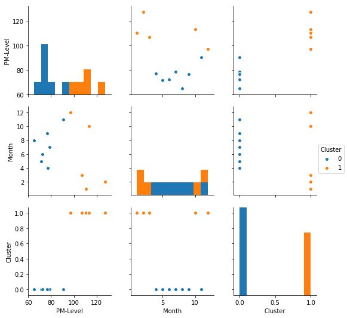

```python
s_time = time.time()

kmeans=KMeans(n_clusters=2).fit(Dataframeofmonthsandpm[["PM-Level"]])
Dataframeofmonthsandpm['Cluster']=kmeans.labels_
g = sns.pairplot(Dataframeofmonthsandpm,hue='Cluster')

e_time = time.time()

print(e_time-s_time)
```

**Check what all Months comes into one category, to cluster them accordingly**

```python
Dataframeofmonthsandpm
```

|  | PM-Level | Month | Cluster |
| --- | --- | --- | --- |
| 0 | 110.575857 | 1 | 1 |
| 1 | 127.658882 | 2 | 1 |
| 2 | 107.123621 | 3 | 1 |
| 3 | 77.121637 | 4 | 0 |
| 4 | 71.503072 | 5 | 0 |
| 5 | 72.318882 | 6 | 0 |
| 6 | 78.790412 | 7 | 0 |
| 7 | 64.815230 | 8 | 0 |
| 8 | 76.463219 | 9 | 0 |
| 9 | 113.616259 | 10 | 1 |
| 10 | 90.578339 | 11 | 0 |
| 11 | 97.036661 | 12 | 1 |

**Create, exta hour cluster column , to group the data accordingly**

```python
def ApplyclusterMonths(row):
    if(int(row["month"])<=3):
        return 0
    elif(int(row["month"])<=9):
        return 1
    elif(int(row["month"])==10):
        return 0
    elif(int(row["month"])==11):
        return 1
    elif(int(row["month"]) == 12):
        return 0
Df["ClusterMonths"] = Df.apply(ApplyclusterMonths, axis=1)
```

**Create **Dummy variables** that would be used in regression, Now our regression will account for this pattern.</b>**

```python
DFDumy[["Dummy1Month","Dummy2Month"]]= pd.get_dummies(Df["ClusterMonths"])
```

```python
s_time = time.time()

import statsmodels.formula.api as sm
result = sm.ols(formula="Average_PM_Level ~ TEMP+PRES+HUMI+Iws+Iprec+Hour_Dummy1+Hour_Dummy2+Dummy1Month", data=DFDumy).fit()
print (result.summary())

e_time = time.time()

print(e_time-s_time)
```

```
                            OLS Regression Results
==============================================================================
Dep. Variable:       Average_PM_Level   R-squared:                       0.292
Model:                            OLS   Adj. R-squared:                  0.292
Method:                 Least Squares   F-statistic:                     983.0
Date:                Sat, 21 Jul 2018   Prob (F-statistic):               0.00
Time:                        08:45:43   Log-Likelihood:            -1.0811e+05
No. Observations:               19062   AIC:                         2.162e+05
Df Residuals:                   19053   BIC:                         2.163e+05
Df Model:                           8
Covariance Type:            nonrobust
===============================================================================
                  coef    std err          t      P>|t|      [0.025      0.975]
-------------------------------------------------------------------------------
Intercept    1328.6561     97.336     13.650      0.000    1137.870    1519.442
TEMP           -1.6240      0.094    -17.358      0.000      -1.807      -1.441
PRES           -1.3035      0.095    -13.761      0.000      -1.489      -1.118
HUMI            1.5280      0.024     62.405      0.000       1.480       1.576
Iws            -0.2109      0.012    -17.964      0.000      -0.234      -0.188
Iprec          -3.9966      0.240    -16.640      0.000      -4.467      -3.526
Hour_Dummy1    36.8182      1.465     25.128      0.000      33.946      39.690
Hour_Dummy2    14.6653      1.210     12.119      0.000      12.293      17.037
Dummy1Month    44.4563      1.562     28.453      0.000      41.394      47.519
==============================================================================
Omnibus:                     5038.081   Durbin-Watson:                   0.127
Prob(Omnibus):                  0.000   Jarque-Bera (JB):            15832.429
Skew:                           1.351   Prob(JB):                         0.00
Kurtosis:                       6.554   Cond. No.                     1.94e+05
==============================================================================

Warnings:
[1] Standard Errors assume that the covariance matrix of the errors is correctly specified.
[2] The condition number is large, 1.94e+05. This might indicate that there are
strong multicollinearity or other numerical problems.
0.06517243385314941
```

```python
s_time = time.time()

from patsy import dmatrices
from statsmodels.stats.outliers_influence import variance_inflation_factor
# get y and X dataframes based on this regression:
y, X = dmatrices("Average_PM_Level ~ TEMP+PRES+HUMI+Iws+Iprec+Hour_Dummy1+Hour_Dummy2+Dummy1Month", DFDumy, return_type='dataframe')
vif = pd.DataFrame()
vif["VIF Factor"] = [variance_inflation_factor(X.values, i) for i in range(X.shape[1])]
vif["features"] = X.columns
vif.round(1)

e_time = time.time()

print(e_time-s_time)
```

```
0.10431456565856934
```

**Tuning the final regression model.**

**Plot the Residual graph, to furthuer tune the model**

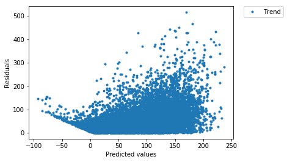

```python
fig = plt.figure()
ax1 = fig.add_subplot(111)
ax1.plot(result.predict(),result.resid.abs(),'.',label="Trend")
plt.xlabel('Predicted values') # Adding the Axes
plt.ylabel('Residuals')# Adding the Axes
plt.legend(bbox_to_anchor=(1.05, 1), loc=2, borderaxespad=0.)
plt.show()
```

- **To decrease the residual values, we will use the **log** of the dependednt variable, to check if the **r(square) value is improved**.**
- **Re run the regression on **np.log(Average_PM_Level)****

```python
s_time = time.time()

import statsmodels.formula.api as sm
result = sm.ols(formula="np.log(Average_PM_Level) ~ TEMP+PRES+HUMI+Iws+Iprec+Hour_Dummy1+Hour_Dummy2+Dummy1Month", data=DFDumy).fit()
print (result.summary())

e_time = time.time()

print(e_time-s_time)
```

```
                               OLS Regression Results
====================================================================================
Dep. Variable:     np.log(Average_PM_Level)   R-squared:                       0.344
Model:                                  OLS   Adj. R-squared:                  0.344
Method:                       Least Squares   F-statistic:                     1248.
Date:                      Sat, 21 Jul 2018   Prob (F-statistic):               0.00
Time:                              08:45:43   Log-Likelihood:                -23942.
No. Observations:                     19062   AIC:                         4.790e+04
Df Residuals:                         19053   BIC:                         4.797e+04
Df Model:                                 8
Covariance Type:                  nonrobust
===============================================================================
                  coef    std err          t      P>|t|      [0.025      0.975]
-------------------------------------------------------------------------------
Intercept      20.1777      1.177     17.145      0.000      17.871      22.484
TEMP           -0.0122      0.001    -10.767      0.000      -0.014      -0.010
PRES           -0.0170      0.001    -14.839      0.000      -0.019      -0.015
HUMI            0.0200      0.000     67.434      0.000       0.019       0.021
Iws            -0.0051      0.000    -35.622      0.000      -0.005      -0.005
Iprec          -0.0487      0.003    -16.766      0.000      -0.054      -0.043
Hour_Dummy1     0.3943      0.018     22.254      0.000       0.360       0.429
Hour_Dummy2     0.2019      0.015     13.800      0.000       0.173       0.231
Dummy1Month     0.4462      0.019     23.622      0.000       0.409       0.483
==============================================================================
Omnibus:                      483.815   Durbin-Watson:                   0.140
Prob(Omnibus):                  0.000   Jarque-Bera (JB):              515.544
Skew:                          -0.396   Prob(JB):                    1.12e-112
Kurtosis:                       2.853   Cond. No.                     1.94e+05
==============================================================================

Warnings:
[1] Standard Errors assume that the covariance matrix of the errors is correctly specified.
[2] The condition number is large, 1.94e+05. This might indicate that there are
strong multicollinearity or other numerical problems.
0.11888527870178223
```

```python
s_time = time.time()

from patsy import dmatrices
from statsmodels.stats.outliers_influence import variance_inflation_factor
# get y and X dataframes based on this regression:
y, X = dmatrices("np.log(Average_PM_Level) ~ TEMP+PRES+HUMI+Iws+Iprec+Hour_Dummy1+Hour_Dummy2+Dummy1Month", DFDumy, return_type='dataframe')
vif = pd.DataFrame()
vif["VIF Factor"] = [variance_inflation_factor(X.values, i) for i in range(X.shape[1])]
vif["features"] = X.columns
vif.round(1)


e_time = time.time()

print(e_time-s_time)
```

```
0.12031841278076172
```

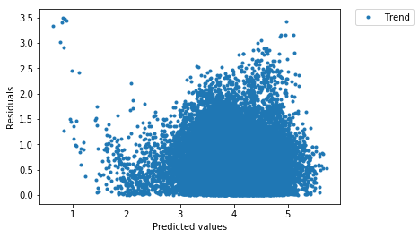

```python
fig = plt.figure()
ax1 = fig.add_subplot(111)
ax1.plot(result.predict(),result.resid.abs(),'.',label="Trend")
plt.xlabel('Predicted values') # Adding the Axes
plt.ylabel('Residuals')# Adding the Axes
plt.legend(bbox_to_anchor=(1.05, 1), loc=2, borderaxespad=0.)
plt.show()
```

**Code-Complexity Analysis with the varying size of the Dataset**

```python
import time
size = np.geomspace(start=100,stop=Beijingdata.count()[1],num=30,dtype=int)
Time = np.zeros(len(size))

for (x, n) in enumerate(size):
    times=np.zeros(50)
    for i in range(50):
        startTime = time.time()
        sm.ols(formula="np.log(Average_PM_Level) ~ TEMP+PRES+HUMI+Iws+Iprec+Hour_Dummy1+Hour_Dummy2+Dummy1Month", data=DFDumy[0:n]).fit()
        endTime = time.time()
        times[i]=endTime-startTime

    Time[x]=np.mean(times)
```

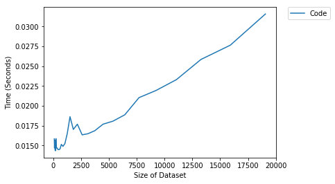

```python
fig = plt.figure()
ax1 = fig.add_subplot(111)
ax1.plot (size, Time, '-',label="Code")
plt.xlabel('Size of Dataset')
plt.ylabel('Time (Seconds)')
plt.legend(bbox_to_anchor=(1.05, 1), loc=2, borderaxespad=0.)
plt.show()
```

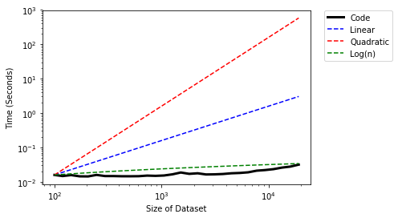

```python
#Create benchmarks
linearTime = [Time[0]/size[0]*n for n in size]
quadraticTime = [(Time[0]/(size[0]**2))*(n**2) for n in size]
lognTime = [Time[0]/(np.log(size[0]))*(np.log(n)) for n in size]

fig = plt.figure()
ax1 = fig.add_subplot(111)
ax1.loglog (size, Time, 'k-',linewidth=3,label="Code")

#Plot benchmarks
ax1.loglog (size, linearTime, 'b--',label="Linear")
ax1.loglog (size, quadraticTime, 'r--',label="Quadratic")
ax1.loglog (size, lognTime, 'g--',label="Log(n)")

plt.xlabel('Size of Dataset')
plt.ylabel('Time (Seconds)')
plt.legend(bbox_to_anchor=(1.05, 1), loc=2, borderaxespad=0.)
plt.show()
```

**From the above graphs it is clear that as datasize increases the processing time to run the linear regression increases.From the graph with the benchmarks, we can easily see the the time complexity of the code follows a logarithm function.**</b>

**Prediction of PM2.5 prone areas across the globe, based on the regression equation**

**To perform this prediction, we downloaded the dataset consisting of **weather, temperature, Dewpoint, Windspeed** and other meterological charecteristics of the cities across the globe.**

- **Read all the data from the weathers json object**
- **Import folium library on to the local machine**
- **If the import fails, it mean library is not installed on your local machine, please use the following code to install folium to the local machine**
- **conda install -c conda-forge folium**

**Download the data from the link provided below, the file will be downloded in your downloads folder.**

https://drive.google.com/file/d/1rt_wOrMJLEpJvDOsUeWN9FHhMDlygGRO/view?usp=sharing

**Place the downloaded file from the download folder to your current working directory. To know what is the current working directory of the note book, please run the following code below**

```python
import os
print(os.getcwd())
```

```
C:\Users\KVR\Documents\Python Scripts\Class examples\Project_Files
```

**C:\Users\KVR\Documents\Python Scripts\Class examples\Project_Files** This represent My **working directory**, Please run the above code to get yours.

```python
import folium
from folium import plugins
import pandas as pd
WeatherDataofCities = pd.read_json("weathers.json", lines =True)
```

**Description of the dataset**

- **city** - City Name
- **lon** : Longitude of the city
- **lat** : Lattitude of the city
- **temp** : Temperature of the city
- **pressure** : Pressure of the city
- **humidity** : Hunidity of the city
- **speed** : Windspeed

**Read all the variables from the json into the dataframe to perform prediction**

```python
place=[]
for i in range(len(WeatherDataofCities.index)):
    place.append(WeatherDataofCities['city'][i]["name"])
lons=[]
for i in range(len(WeatherDataofCities.index)):
    lons.append(WeatherDataofCities['city'][i]["coord"]["lon"])
lats=[]
for i in range(len(WeatherDataofCities.index)):
    lats.append(WeatherDataofCities['city'][i]["coord"]["lat"])
temperature=[]
for i in range(len(WeatherDataofCities.index)):
    temperature.append(WeatherDataofCities['main'][i]["temp"]-273)
pres=[]
for i in range(len(WeatherDataofCities.index)):
    pres.append(WeatherDataofCities['main'][i]["pressure"])
humi=[]
for i in range(len(WeatherDataofCities.index)):
    humi.append(WeatherDataofCities['main'][i]["humidity"])
iws=[]
for i in range(len(WeatherDataofCities.index)):
    iws.append(WeatherDataofCities['wind'][i]["speed"])

ivs = ["place","lons","lats","temperature","pres","humi","iws"]
Weatherdataframe = pd.DataFrame([place,lons,lats,temperature,pres,humi,iws],index = ivs).T
```

```python
def getPM(entry):
    PM = 20.6666 -0.0145*entry[3]-0.0174*entry[4]+0.02*entry[5]-0.005*entry[6]+0.39*entry[7]+0.20*entry[8]+0.38*entry[9]
    return PM
```

**Create a function that performs the complex operation on each row and returns PM2.5 level**

```python
cols = ["place","lons","lats","temperature","pres","humi","iws","dummyH1","dummyH2","dummyM"]
def item(i):
    return [Weatherdataframe.loc[i,m] for m in cols]

from datetime import datetime
Weatherdataframe["dummyH1"]=[0]*len(Weatherdataframe.index)#make a note of the DUmmy based on the dummyH1 and dummyH2
Weatherdataframe["dummyH2"]=[0]*len(Weatherdataframe.index)
Weatherdataframe["dummyM"]=[0]*len(Weatherdataframe.index)#Make a note of the month based on the value of dummyM
things = list(item(i)for i in range(len(Weatherdataframe.index)))
Weatherdataframe["PMlevel"]=list(map(getPM,things))
```

**Plot the heatmap with the PM levels based on the **lattitude** and the **longitude** of the city and the PM level</b>**

```python
import numpy as np
line = np.percentile(Weatherdataframe["PMlevel"],95)
draw = Weatherdataframe[Weatherdataframe["PMlevel"]>line]
heatmap = folium.Map(location=[0, 0], zoom_start=3)
heatmap.add_child(plugins.HeatMap([[ row["lats"], row["lons"]] for PMlevel, row in draw.iterrows()]))
```

[interactive chart not shown]

**The heatmap depicts different cities across the planet, and **red** color depicts the regions that are **highly** prone to PM2.5 Level, and **green** depicts region that are **least** prone to PM2.5 compared to the ones in the graph.</b>**

**These kind of prediction heatmaps would help us to understand the PM2.5 levels on a global scale, which would allow us to device new laws and policies in those regions to take necessary actions against PM2.5**

**Recommendations**

- **The regression model for our analysis showed an r-square of 34.4%. Predicting real world data with accuracy using liner models is a tough job to acheive.**
- We imporved the **linear model** as much as we can to account for all the possible patterns in the data and remove **multicollinearity** between variable, to acheive maximum precision on the predict.</b>
- However using **NON -linear modelling** could be stastically appropriate analysis on the Impact of weather data on PM2.5</b>
- **We made an attempt to address this with a non - linear model, However as class dealt with only linear models, **we restricted the scope of analysis only to the linear models.****

**Non-linear Modelling test on Impact of independent variables on PM2.5**

```python
s_time = time.time()

import statsmodels.formula.api as sm
result = sm.ols(formula="np.log(Average_PM_Level) ~ TEMP+np.power(PRES,2)+np.power(HUMI,-1)+np.power(Iws,-1)+Iprec+Hour_Dummy1+Hour_Dummy2+Dummy1Month+np.power(TEMP,2)*PRES*HUMI*Iws*np.power(Iprec,-2)*Hour_Dummy1*Hour_Dummy2*Dummy1Month", data=DFDumy).fit()
print (result.summary())

e_time = time.time()

print(e_time-s_time)
```

```
                               OLS Regression Results
====================================================================================
Dep. Variable:     np.log(Average_PM_Level)   R-squared:                       0.577
Model:                                  OLS   Adj. R-squared:                  0.422
Method:                       Least Squares   F-statistic:                     3.721
Date:                      Sat, 21 Jul 2018   Prob (F-statistic):           2.79e-29
Time:                              08:49:21   Log-Likelihood:                -513.49
No. Observations:                       638   AIC:                             1371.
Df Residuals:                           466   BIC:                             2138.
Df Model:                               171
Covariance Type:                  nonrobust
===========================================================================================================================================================
                                                                                              coef    std err          t      P>|t|      [0.025      0.975]
-----------------------------------------------------------------------------------------------------------------------------------------------------------
Intercept                                                                                3544.3874   1161.050      3.053      0.002    1262.845    5825.930
TEMP                                                                                       -0.2706      0.050     -5.455      0.000      -0.368      -0.173
np.power(PRES, 2)                                                                           0.0034      0.001      3.164      0.002       0.001       0.006
np.power(HUMI, -1)                                                                         70.8035     36.555      1.937      0.053      -1.030     142.637
np.power(Iws, -1)                                                                           0.1353      0.098      1.379      0.168      -0.057       0.328
Iprec                                                                                      -0.0155      0.003     -4.490      0.000      -0.022      -0.009
Hour_Dummy1                                                                               414.9466    422.502      0.982      0.327    -415.299    1245.192
Hour_Dummy2                                                                               273.0365    388.196      0.703      0.482    -489.794    1035.867
Dummy1Month                                                                               150.1194    300.140      0.500      0.617    -439.676     739.915
np.power(TEMP, 2)                                                                           0.7150      0.870      0.822      0.412      -0.995       2.425
PRES                                                                                       -6.9448      2.210     -3.142      0.002     -11.288      -2.602
np.power(TEMP, 2):PRES                                                                     -0.0007      0.001     -0.830      0.407      -0.002       0.001
HUMI                                                                                       -1.9647      4.134     -0.475      0.635     -10.088       6.158
np.power(TEMP, 2):HUMI                                                                     -0.0062      0.010     -0.621      0.535      -0.026       0.013
PRES:HUMI                                                                                   0.0019      0.004      0.460      0.645      -0.006       0.010
np.power(TEMP, 2):PRES:HUMI                                                              6.312e-06   9.85e-06      0.641      0.522    -1.3e-05    2.57e-05
Iws                                                                                        24.3888     21.224      1.149      0.251     -17.319      66.096
np.power(TEMP, 2):Iws                                                                      -0.1288      0.074     -1.735      0.083      -0.275       0.017
PRES:Iws                                                                                   -0.0246      0.021     -1.168      0.243      -0.066       0.017
np.power(TEMP, 2):PRES:Iws                                                                  0.0001    7.4e-05      1.741      0.082   -1.66e-05       0.000
HUMI:Iws                                                                                   -0.2303      0.229     -1.006      0.315      -0.680       0.219
np.power(TEMP, 2):HUMI:Iws                                                                  0.0014      0.001      1.768      0.078      -0.000       0.003
PRES:HUMI:Iws                                                                               0.0002      0.000      1.026      0.305      -0.000       0.001
np.power(TEMP, 2):PRES:HUMI:Iws                                                         -1.441e-06   8.12e-07     -1.775      0.077   -3.04e-06    1.54e-07
np.power(Iprec, -2)                                                                         4.8154      8.353      0.577      0.565     -11.598      21.229
np.power(TEMP, 2):np.power(Iprec, -2)                                                      -0.0215      0.024     -0.907      0.365      -0.068       0.025
```

[output cut: 232 more lines]

```
np.power(TEMP, 2):HUMI:Iws:np.power(Iprec, -2):Hour_Dummy1:Hour_Dummy2:Dummy1Month               0          0        nan        nan           0           0
PRES:HUMI:Iws:np.power(Iprec, -2):Hour_Dummy1:Hour_Dummy2:Dummy1Month                            0          0        nan        nan           0           0
np.power(TEMP, 2):PRES:HUMI:Iws:np.power(Iprec, -2):Hour_Dummy1:Hour_Dummy2:Dummy1Month          0          0        nan        nan           0           0
==============================================================================
Omnibus:                       30.953   Durbin-Watson:                   0.837
Prob(Omnibus):                  0.000   Jarque-Bera (JB):               55.268
Skew:                          -0.335   Prob(JB):                     9.97e-13
Kurtosis:                       4.276   Cond. No.                     1.07e+16
==============================================================================

Warnings:
[1] Standard Errors assume that the covariance matrix of the errors is correctly specified.
[2] The condition number is large, 1.07e+16. This might indicate that there are
strong multicollinearity or other numerical problems.
20.20587921142578
```